# Prediction Models for Extramarital Affairs

## Preliminaries

```r
library(skimr)
library(broom)
library(MASS)
library(lars)
library(modelr)
library(leaps)
library(rms)
library(ROCR)
library(forcats)
library(tidyverse)
```

# Task 1: Data Source

The source of my data is a 1978 study titled, “A Theory of Extramarital Affairs” by R.C Fair published in the “Journal of Political Economy”, however I accessed the data through the R package, “Wooldridge”. The information for this R package can be found at the url [here](https://cran.r-project.org/web/packages/wooldridge/wooldridge.pdf). The link for the original publication can be found [here](http://www.journals.uchicago.edu/doi/10.1086/260646).

# Task 2: Load and Tidy the Data

```r
affairs_data <- read.csv("Affairs.csv") %>% tbl_df %>%
#relabel affair
  mutate(affair = fct_recode(factor(affair), Yes = "1", No = "0")) %>%
#relabel relig
  mutate(relig = fct_recode(factor(relig), Very = "5", Somewhat = "4", Slightly = "3",  No = "2", Anti = "1")) %>%
  mutate(ratemarr = fct_recode(factor(ratemarr), Very_Unhappy = "1", Somewhat_Unhappy = "2", Average = "3", Happier_than_Average = "4", Very_Happy = "5")) %>%
  #Make id a factor
  mutate(id = factor(id)) %>%
  #round age to a whole number
  mutate(age = round(age, 0)) %>%
  #select variables for analysis
  select(id, male, age, yrsmarr, kids, relig, educ, ratemarr, naffairs, affair)
```

To tidy my data, I first recoded the affair category which was originally listed as ones and zeros to Yes (1), and No (0). This way it is easier to understand the binary outcome. I also recoded the categorical variables for religion and marriage ratings so that they are easier to interperet. I also made id a factor, rounded everyone’s age to a whole number, and removed the variables in the dataset that I do not intend to use in my analysis.

# Task 3: Listing of My Tibble

```r
str(affairs_data)
```

```
Classes 'tbl_df', 'tbl' and 'data.frame':   601 obs. of  10 variables:
 $ id      : Factor w/ 601 levels "4","5","6","11",..: 1 2 3 4 5 6 7 8 9 10 ...
 $ male    : int  1 0 1 0 0 1 1 0 1 0 ...
 $ age     : num  37 27 27 32 27 57 22 32 37 22 ...
 $ yrsmarr : num  10 4 1.5 15 4 15 0.75 1.5 15 0.75 ...
 $ kids    : int  0 0 0 1 1 1 0 0 1 0 ...
 $ relig   : Factor w/ 5 levels "Anti","No","Slightly",..: 3 4 3 1 3 5 2 2 5 2 ...
 $ educ    : int  18 14 18 12 17 18 17 17 18 12 ...
 $ ratemarr: Factor w/ 5 levels "Very_Unhappy",..: 4 4 4 4 5 5 3 5 2 3 ...
 $ naffairs: int  0 0 3 0 3 0 0 0 7 0 ...
 $ affair  : Factor w/ 2 levels "No","Yes": 1 1 2 1 2 1 1 1 2 1 ...
```

```r
summary(affairs_data)
```

```
       id           male             age           yrsmarr
 4      :  1   Min.   :0.0000   Min.   :18.00   Min.   : 0.125
 5      :  1   1st Qu.:0.0000   1st Qu.:27.00   1st Qu.: 4.000
 6      :  1   Median :0.0000   Median :32.00   Median : 7.000
 11     :  1   Mean   :0.4759   Mean   :32.49   Mean   : 8.178
 12     :  1   3rd Qu.:1.0000   3rd Qu.:37.00   3rd Qu.:15.000
 16     :  1   Max.   :1.0000   Max.   :57.00   Max.   :15.000
 (Other):595
      kids             relig          educ
 Min.   :0.0000   Anti    : 48   Min.   : 9.00
 1st Qu.:0.0000   No      :164   1st Qu.:14.00
 Median :1.0000   Slightly:129   Median :16.00
 Mean   :0.7155   Somewhat:190   Mean   :16.17
 3rd Qu.:1.0000   Very    : 70   3rd Qu.:18.00
 Max.   :1.0000                  Max.   :20.00

                 ratemarr      naffairs      affair
 Very_Unhappy        : 16   Min.   : 0.000   No :451
 Somewhat_Unhappy    : 66   1st Qu.: 0.000   Yes:150
 Average             : 93   Median : 0.000
 Happier_than_Average:194   Mean   : 1.456
 Very_Happy          :232   3rd Qu.: 0.000
                            Max.   :12.000
```

# Task 4: Code Book

[output not shown]

# Task 5: My Subjects

The data describe a subset of both men and women who voluntarily responded to a magazine survey. The data on men was collected in 1969 and the survey for women was collected in 1970. The men’s questionaire recieved 20,000 responses and the female questionaire recieved 100,000. All of the participants included in the study dataset were married and in their first marriage. They were also all employed and did not leave any answers blank on the questionaire.

# Task 6: My Variables

Column 1 (id) contains the id number of each person included in the subset of data. Column 2 (male) lists whether the subjects are male or female. Men are coded as a 1 and females are coded as a 0. Column 3 (age) describes the age of the participants. This data was tidied so that age was recorded as an integer. Column 4 (yrsmarr) describes the number of years a couple has been married. People answered this question to the month, so there are non-integer values. All subjects in the study had to have been married, so there are no zero values. Column 5 (kids) describes whether the married couple has children. It does not ask how many children the couple has, rather it is a binary variable. Column 6 (relig) is a categorical variable that asks how religious the participants view themelves as being. column 7 (educ) describes how many years of schooling the participants have had. Column 8 (ratemarr) asks the participants to rate the happiness of their marriage by comparing it to how happy they percieve other couples to be. Column 9 (naffairs) asks how many affairs a person has had within the last year. Column 10 assesses whether a person has had an affair or has not had an affair in the last year.

# Task 7: My Planned Linear Regression Model

The quantitative variable I will use for my outcome is the number of affairs a person has had in the past year (naffairs). I will use ‘age’, ‘kids’, ‘yrsmarr’, ‘relig’, ‘educ’ , and ‘ratemarr’ as my predictor variables in my linear regression model.

# Task 8: My Planned Logistic Regression Model

The binary variable I will use for my outcome is whether a person has had in the past year (affair). I will use ‘age’, ‘kids’, ‘yrsmarr’, ‘relig’, ‘educ’ , and ‘ratemarr’ as my predictor variables in my linear regression model.

# Task 9: Affirmation

My dataset is shareable with the world (it is available in an R package). It has 601 complete data observations, includes a quantitative outcome, and includes a binary outcome. There are 7 predictor variables: two are multi-categorical, 3 are quantitative, and 2 are binary.

- I am certain that it is completely appropriate for these data to be shared with anyone, without any conditions. There are no concerns about privacy or security.

# Task 10 Analysis: Linear Regression

The first approach I will use in creating my regression model is a “best subsets” approach to find the most meaningful variables.

The tibble below shows each model including a varied number of predictors.

```r
bs_preds <- with(affairs_data, cbind(male, age, yrsmarr, kids, relig, educ, ratemarr))
bs_subs <- regsubsets(bs_preds,
                      y = affairs_data$naffairs,
                      nvmax = 7)
bs_mods <- summary(bs_subs)

bs_winners <- tbl_df(bs_mods$which)
bs_winners$k <- 2:8
bs_winners$r2 <- bs_mods$rsq
bs_winners$adjr2 <- bs_mods$adjr2
bs_winners$cp <- bs_mods$cp
bs_winners$bic <- bs_mods$bic

#aic corrected
temp.n <- nrow(affairs_data)
temp.inputs <- 8

bs_mods$aic.corr <- temp.n*log(bs_mods$rss / temp.n) +
    2*(2:temp.inputs) +
    (2 * (2:temp.inputs) * ((2:temp.inputs)+1) /
         (temp.n - (2:temp.inputs) - 1))

bs_winners$aic.corr <- bs_mods$aic.corr
bs_winners
```

```
# A tibble: 7 x 14
  `(Intercept)` male  age   yrsmarr kids  relig educ  ratemarr     k
  <lgl>         <lgl> <lgl> <lgl>   <lgl> <lgl> <lgl> <lgl>    <int>
1 T             F     F     F       F     F     F     T            2
2 T             F     F     F       F     T     F     T            3
3 T             F     F     T       F     T     F     T            4
4 T             F     T     T       F     T     F     T            5
5 T             T     T     T       F     T     F     T            6
6 T             T     T     T       T     T     F     T            7
7 T             T     T     T       T     T     T     T            8
# ... with 5 more variables: r2 <dbl>, adjr2 <dbl>, cp <dbl>, bic <dbl>,
#   aic.corr <dbl>
```

The graphs below show which model had the best corrected AIC, BIC, adjusted R squared, and Cp plot.

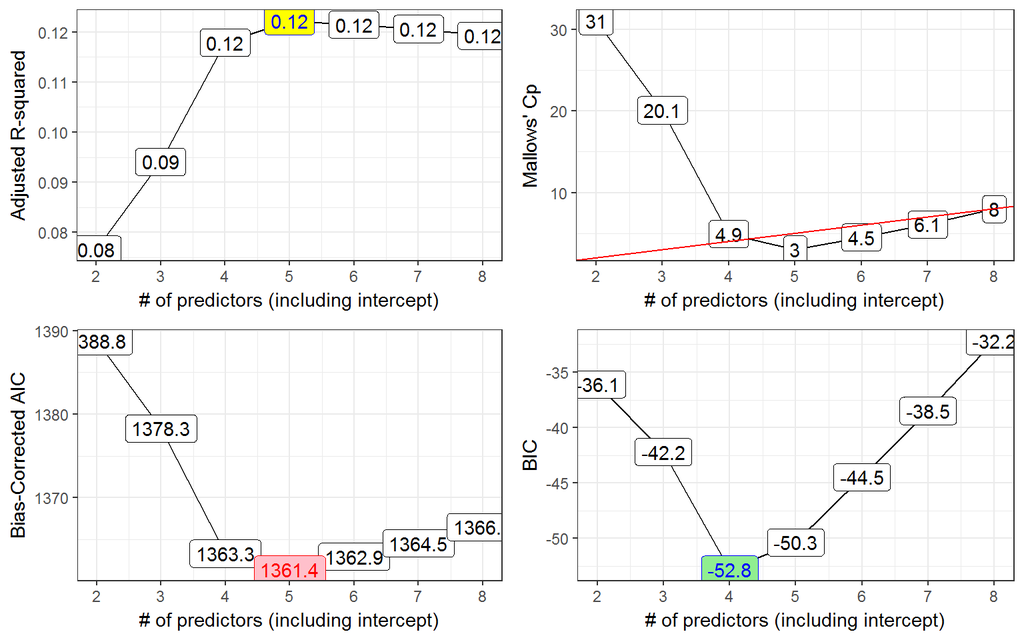

```r
p1 <- ggplot(bs_winners, aes(x = k, y = adjr2,
                            label = round(adjr2,2))) +
    geom_line() +
    geom_label() +
    geom_label(data = subset(bs_winners,
                             adjr2 == max(adjr2)),
               aes(x = k, y = adjr2, label = round(adjr2,2)),
               fill = "yellow", col = "blue") +
    theme_bw() +
    scale_x_continuous(breaks = 2:9) +
    labs(x = "# of predictors (including intercept)",
         y = "Adjusted R-squared")
p2 <- ggplot(bs_winners, aes(x = k, y = cp,
                            label = round(cp,1))) +
    geom_line() +
    geom_label() +
    geom_abline(intercept = 0, slope = 1,
                col = "red") +
    theme_bw() +
    scale_x_continuous(breaks = 2:9) +
    labs(x = "# of predictors (including intercept)",
         y = "Mallows' Cp")

p3 <- ggplot(bs_winners, aes(x = k, y = aic.corr,
                             label = round(aic.corr,1))) +
    geom_line() +
    geom_label() +
    geom_label(data = subset(bs_winners, aic.corr == min(aic.corr)),
               aes(x = k, y = aic.corr), fill = "pink",
               col = "red") +
    theme_bw() +
    scale_x_continuous(breaks = 2:9) +
    labs(x = "# of predictors (including intercept)",
         y = "Bias-Corrected AIC")

p4 <- ggplot(bs_winners, aes(x = k, y = bic,
                            label = round(bic,1))) +
    geom_line() +
    geom_label() +
    geom_label(data = subset(bs_winners, bic == min(bic)),
               aes(x = k, y = bic),
               fill = "lightgreen", col = "blue") +
    theme_bw() +
    scale_x_continuous(breaks = 2:9) +
    labs(x = "# of predictors (including intercept)",
         y = "BIC")
gridExtra::grid.arrange(p1, p2, p3, p4, nrow = 2)
```

Next, a cross validation will be conducted for the two models to determine which performs better with varied subsets of data.

```r
set.seed(43201)

m4x <- affairs_data %>%
  crossv_kfold(k = 5) %>%
  mutate(model = map(train,
                     ~ lm(naffairs ~ age + yrsmarr + relig + ratemarr, data = .)))

m4x_pred <- m4x %>%
  unnest(map2(model, test, ~ augment(.x, newdata = .y)))

res4 <- m4x_pred %>%
  summarize(Model = "4",
            RMSE = sqrt(mean((naffairs - .fitted) ^2)),
            MAE = mean(abs(naffairs - .fitted)))
```

```r
set.seed(43202)

m5x <- affairs_data %>%
  crossv_kfold(k = 5) %>%
  mutate(model = map(train,
                     ~ lm(naffairs ~ age + yrsmarr + relig + ratemarr + male, data = .)))

m5x_pred <- m5x %>%
  unnest(map2(model, test, ~ augment(.x, newdata = .y)))

res5 <- m5x_pred %>%
  summarize(Model = "5",
            RMSE = sqrt(mean((naffairs - .fitted) ^2)),
            MAE = mean(abs(naffairs - .fitted)))
```

```r
bind_rows(res4, res5)
```

```
# A tibble: 2 x 3
  Model  RMSE   MAE
  <chr> <dbl> <dbl>
1 4      3.11  2.02
2 5      3.08  2.02
```

Shown below is a final summary of the linear model.

```r
summary((m5 <- lm(naffairs ~ age + yrsmarr + relig + ratemarr + male, data = affairs_data)))
```

```
Call:
lm(formula = naffairs ~ age + yrsmarr + relig + ratemarr + male,
    data = affairs_data)

Residuals:
    Min      1Q  Median      3Q     Max
-4.9713 -1.5706 -0.6861  0.1370 12.7359

Coefficients:
                             Estimate Std. Error t value Pr(>|t|)
(Intercept)                   4.92938    1.03892   4.745 2.62e-06 ***
age                          -0.04703    0.02240  -2.100 0.036183 *
yrsmarr                       0.16009    0.03730   4.292 2.07e-05 ***
religNo                      -1.11891    0.50616  -2.211 0.027448 *
religSlightly                -0.90307    0.52090  -1.734 0.083498 .
religSomewhat                -2.02220    0.49823  -4.059 5.60e-05 ***
religVery                    -2.02113    0.58233  -3.471 0.000557 ***
ratemarrSomewhat_Unhappy      0.26964    0.85640   0.315 0.752982
ratemarrAverage              -2.04800    0.83636  -2.449 0.014627 *
ratemarrHappier_than_Average -2.22768    0.80359  -2.772 0.005745 **
ratemarrVery_Happy           -2.54802    0.80714  -3.157 0.001676 **
male                          0.23011    0.26179   0.879 0.379761
---
Signif. codes:  0 '***' 0.001 '**' 0.01 '*' 0.05 '.' 0.1 ' ' 1

Residual standard error: 3.061 on 589 degrees of freedom
Multiple R-squared:  0.1548,    Adjusted R-squared:  0.139
F-statistic: 9.808 on 11 and 589 DF,  p-value: < 2.2e-16
```

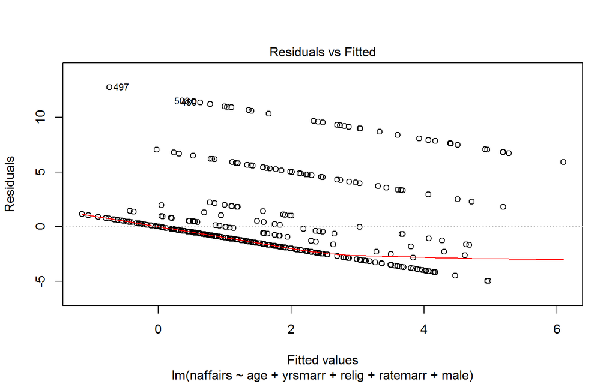

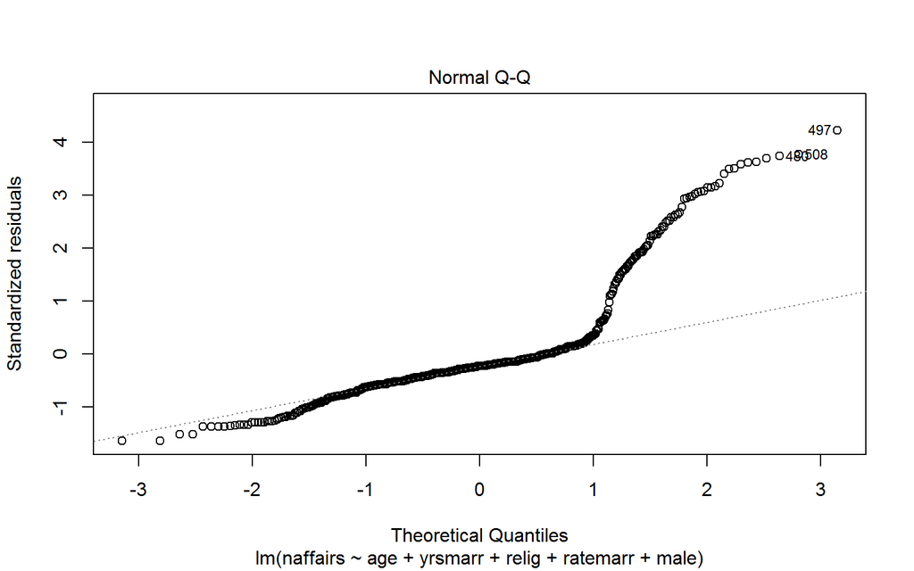

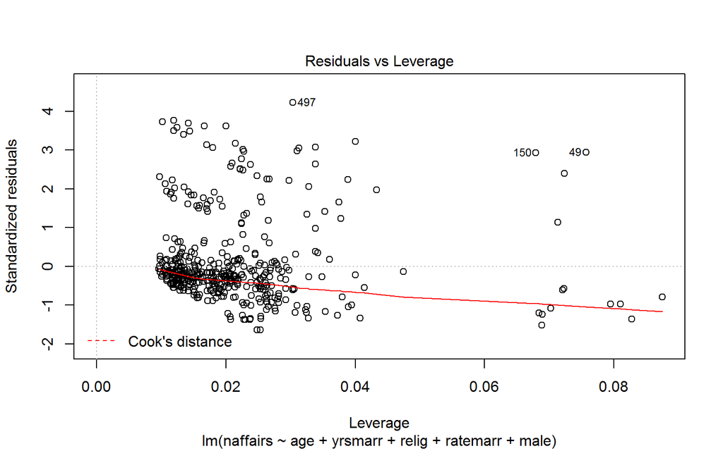

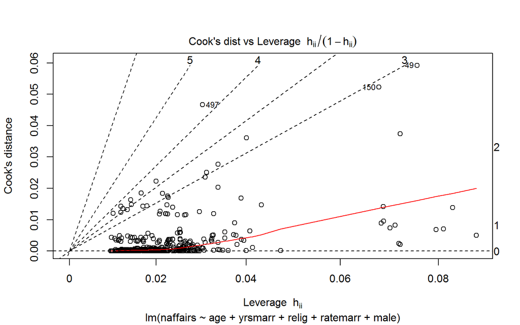

```r
plot(m5, which = c(1,2,5,6))
```

```r
Hmisc::describe(affairs_data$affair)
```

```
affairs_data$affair
       n  missing distinct
     601        0        2

Value        No  Yes
Frequency   451  150
Proportion 0.75 0.25
```

# Task 11: Logistic Regression

In my logistic regression model, the outcome will be whether or not someone has had an affair. I will use rlm in this model.

### glm

```r
res_mod1 <- glm(affair ~ age + yrsmarr + relig + ratemarr + male + kids
                + educ, data = affairs_data, family = binomial)
res_mod1
```

```
Call:  glm(formula = affair ~ age + yrsmarr + relig + ratemarr + male +
    kids + educ, family = binomial, data = affairs_data)

Coefficients:
                 (Intercept)                           age
                    0.632975                     -0.042293
                     yrsmarr                       religNo
                    0.094482                     -0.975707
               religSlightly                 religSomewhat
                   -0.594373                     -1.527868
                   religVery      ratemarrSomewhat_Unhappy
                   -1.420058                      0.009337
             ratemarrAverage  ratemarrHappier_than_Average
                   -0.853566                     -1.158973
          ratemarrVery_Happy                          male
                   -1.654397                      0.326483
                        kids                          educ
                    0.342783                      0.029837

Degrees of Freedom: 600 Total (i.e. Null);  587 Residual
Null Deviance:      675.4
Residual Deviance: 599.2    AIC: 627.2
```

```r
res_1_aug <- augment(res_mod1, affairs_data,
                     type.predict = "response")
```

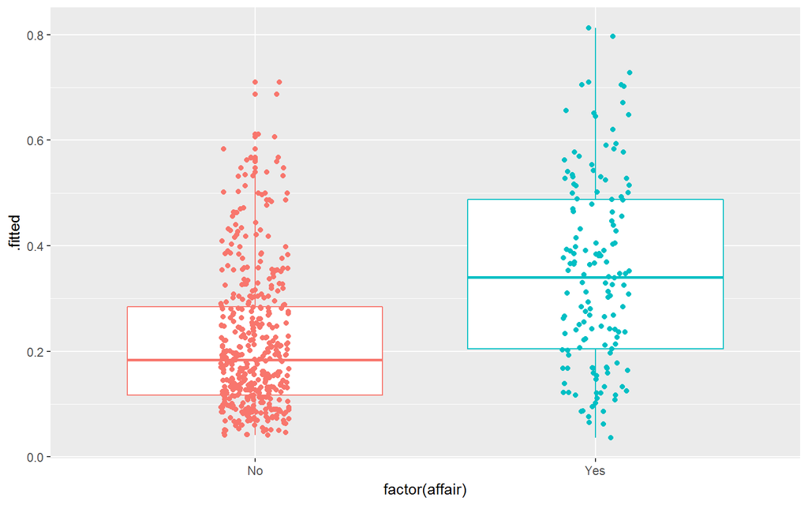

```r
ggplot(res_1_aug, aes(x = factor(affair), y = .fitted, col = factor(affair))) +
    geom_boxplot() +
    geom_jitter(width = 0.1) +
    guides(col = FALSE)
```

### lrm

```r
dd <- datadist(affairs_data)
options(datadist="dd")

res_mod2 <- lrm(affair ~ age + yrsmarr + relig + ratemarr + male + kids + educ, data=affairs_data, x=TRUE, y=TRUE)
res_mod2
```

```
Logistic Regression Model

 lrm(formula = affair ~ age + yrsmarr + relig + ratemarr + male +
     kids + educ, data = affairs_data, x = TRUE, y = TRUE)

                       Model Likelihood     Discrimination    Rank Discrim.
                          Ratio Test           Indexes           Indexes
 Obs           601    LR chi2      76.18    R2       0.176    C       0.724
  No           451    d.f.            13    g        0.997    Dxy     0.448
  Yes          150    Pr(> chi2) <0.0001    gr       2.710    gamma   0.448
 max |deriv| 1e-05                          gp       0.170    tau-a   0.168
                                            Brier    0.162

                               Coef    S.E.   Wald Z Pr(>|Z|)
 Intercept                      0.6330 0.9767  0.65  0.5169
 age                           -0.0423 0.0185 -2.29  0.0223
 yrsmarr                        0.0945 0.0328  2.88  0.0040
 relig=No                      -0.9757 0.3672 -2.66  0.0079
 relig=Slightly                -0.5944 0.3701 -1.61  0.1082
 relig=Somewhat                -1.5279 0.3738 -4.09  <0.0001
 relig=Very                    -1.4201 0.4535 -3.13  0.0017
 ratemarr=Somewhat_Unhappy      0.0093 0.5836  0.02  0.9872
 ratemarr=Average              -0.8536 0.5781 -1.48  0.1398
 ratemarr=Happier_than_Average -1.1590 0.5591 -2.07  0.0382
 ratemarr=Very_Happy           -1.6544 0.5703 -2.90  0.0037
 male                           0.3265 0.2281  1.43  0.1524
 kids                           0.3428 0.2950  1.16  0.2452
 educ                           0.0298 0.0464  0.64  0.5198
```

```r
set.seed(432001)
validate(res_mod2, B = 100)
```

```
          index.orig training    test optimism index.corrected   n
Dxy           0.4481   0.4846  0.4184   0.0662          0.3819 100
R2            0.1764   0.2082  0.1525   0.0557          0.1207 100
Intercept     0.0000   0.0000 -0.1586   0.1586         -0.1586 100
Slope         1.0000   1.0000  0.8331   0.1669          0.8331 100
Emax          0.0000   0.0000  0.0699   0.0699          0.0699 100
D             0.1251   0.1501  0.1070   0.0431          0.0820 100
U            -0.0033  -0.0033  0.0047  -0.0081          0.0047 100
Q             0.1284   0.1534  0.1023   0.0511          0.0773 100
B             0.1620   0.1571  0.1667  -0.0096          0.1716 100
g             0.9971   1.1114  0.9125   0.1988          0.7983 100
gp            0.1703   0.1835  0.1577   0.0259          0.1445 100
```

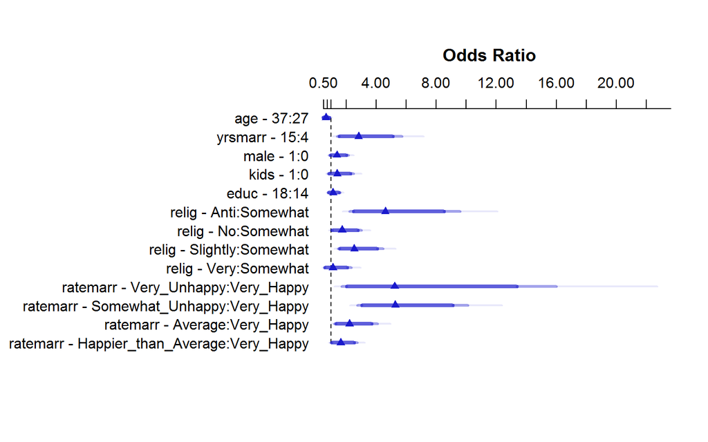

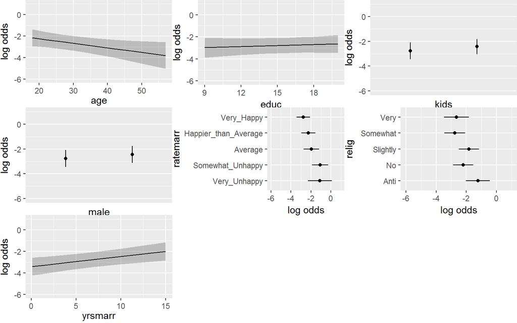

```r
plot(summary(res_mod2))
ggplot(Predict(res_mod2))
```

```r
anova(res_mod2)
```

```
                Wald Statistics          Response: affair

 Factor     Chi-Square d.f. P
 age         5.22       1   0.0223
 yrsmarr     8.31       1   0.0040
 relig      22.16       4   0.0002
 ratemarr   29.29       4   <.0001
 male        2.05       1   0.1524
 kids        1.35       1   0.2452
 educ        0.41       1   0.5198
 TOTAL      64.70      13   <.0001
```

### spearman rho to test for non-linearity

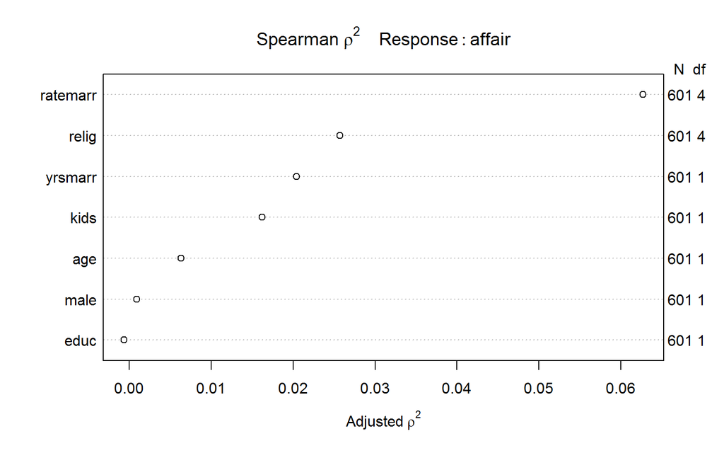

```r
plot(Hmisc::spearman2(affair ~ age + yrsmarr + relig + ratemarr + male + educ + kids, data = affairs_data))
```

Based on this plot, ratemarr is the best candidate for a potential predictive punch to consider for non-linearity.

Estee Cramer